# Data 607 Project 2

Sung Lee

3/2/2020

[Assignment on RPubs](https://rpubs.com/logicalschema/data607_project2)  
[Rmd on GitHub](https://github.com/logicalschema/DATA607/blob/master/Project%202/Sung-Lee-Project2.Rmd)

# Introduction

The purpose of this project is to work with three datasets, tidy the data, and repurpose for data analysis. The three datasets I will use are: Leo Yi’s climate data from https:/www.usclimatedata.com, Philip Tanofsky’s Coronavirus data https://github.com/CryptoKass/ncov-data/blob/master/world.latest.bno.csv, and Gehad Gad’s Academic Advising data https://raw.githubusercontent.com/logicalschema/DATA607/master/Project%202/Advising.png.

If you wish to see the R code used, there is a `Code` button in each section to view the code.

I will use the following R libraries.

```r
library(stringr)
library(tidyr)
library(dplyr)
```

```r
library(ggplot2)
library(rvest)  #This R library allows you to scrap web pages
```

# Climate Data

The original climate data comes from https:/www.usclimatedata.com for New York-La Guardia Airport New York. I saved the page as html and saved in my GitHub account. Because the data is in HTML tables, I will scrap the data and reconstruct the data into a format that is usable. This will be done using the `rvest` library.

## Importing

```r
climateHTML <- read_html("https://raw.githubusercontent.com/logicalschema/DATA607/master/Project%202/usclimatedata.html")

#Read in the specific HTML nodes that have our data
climateTableOne <- html_nodes(climateHTML, "#monthly_table_one") %>% html_table()
climateTableTwo <- html_nodes(climateHTML, "#monthly_table_two") %>% html_table()
```

Here is a look at the imported data:

```r
climateTableOne
```

```
## [[1]]
##                                            JanJa FebFe MarMa AprAp MayMa JunJu
## 1             Average high in ºFAv. highHi 39.00 42.00 50.00    61 71.00 80.00
## 2               Average low in ºFAv. lowLo 27.00 29.00 35.00    44 54.00 64.00
## 3 Av. precipitation in inchAv. precip.Pre.  3.17  2.76  3.97     4  3.79  3.94
## 4           Av. snowfall in inchSnowfallSn  7.00  9.00  4.00     1  0.00  0.00
```

```r
climateTableTwo
```

```
## [[1]]
##                                            JulJu AugAu SepSe OctOc NovNo DecDe
## 1             Average high in ºFAv. highHi  85.0 84.00 76.00 65.00 55.00 44.00
## 2               Average low in ºFAv. lowLo  69.0 69.00 62.00 51.00 42.00 32.00
## 3 Av. precipitation in inchAv. precip.Pre.   4.5  4.12  3.73  3.78  3.41  3.56
## 4           Av. snowfall in inchSnowfallSn   0.0  0.00  0.00  0.00  0.00  5.00
```

## Tidying

Let’s merge the two tables.

```r
climateData <- merge(climateTableOne, climateTableTwo)
```

Here is a view of the data.

```r
climateData
```

| Var.1 | JanJa | FebFe | MarMa | AprAp | MayMa | JunJu | JulJu | AugAu | SepSe | OctOc | NovNo | DecDe |
| --- | --- | --- | --- | --- | --- | --- | --- | --- | --- | --- | --- | --- |
| Av. precipitation in inchAv. precip.Pre. | 3.17 | 2.76 | 3.97 | 4 | 3.79 | 3.94 | 4.5 | 4.12 | 3.73 | 3.78 | 3.41 | 3.56 |
| Av. snowfall in inchSnowfallSn | 7.00 | 9.00 | 4.00 | 1 | 0.00 | 0.00 | 0.0 | 0.00 | 0.00 | 0.00 | 0.00 | 5.00 |
| Average high in ºFAv. highHi | 39.00 | 42.00 | 50.00 | 61 | 71.00 | 80.00 | 85.0 | 84.00 | 76.00 | 65.00 | 55.00 | 44.00 |
| Average low in ºFAv. lowLo | 27.00 | 29.00 | 35.00 | 44 | 54.00 | 64.00 | 69.0 | 69.00 | 62.00 | 51.00 | 42.00 | 32.00 |

Let’s rename the columns:

```r
#Rename the columns "JanJa" "FebFe" "MarMa" "AprAp" "MayMa" "JunJu" "JulJu" "AugAu" "SepSe" "OctOc" "NovNo" "DecDe"
climateData <- rename(climateData, "Jan" = "JanJa")
climateData <- rename(climateData, "Feb" = "FebFe")
climateData <- rename(climateData, "Mar" = "MarMa")
climateData <- rename(climateData, "Apr" = "AprAp")
climateData <- rename(climateData, "May" = "MayMa")
climateData <- rename(climateData, "Jun" = "JunJu")
climateData <- rename(climateData, "Jul" = "JulJu")
climateData <- rename(climateData, "Aug" = "AugAu")
climateData <- rename(climateData, "Sep" = "SepSe")
climateData <- rename(climateData, "Oct" = "OctOc")
climateData <- rename(climateData, "Nov" = "NovNo")
climateData <- rename(climateData, "Dec" = "DecDe")
```

Let’s convert the month columns to rows and the rows for column `Var.1` to individual columns.

```r
#Convert the columns from Jan to Dec as row values and retain the value
climateData <- gather(climateData, key = "Month", value = "Number", "Jan":"Dec" )

#Convert the rows in the column Var.1 to column and retain the value
climateData <- spread(climateData, "Var.1", "Number")

#Rename the columns
climateData <- rename(climateData, "Av Precip" = "Av. precipitation in inchAv. precip.Pre.")
climateData <- rename(climateData, "Av Snowfall in inches" = "Av. snowfall in inchSnowfallSn")
climateData <- rename(climateData, "Av High in ºF" = "Average high in ºFAv. highHi")
climateData <- rename(climateData, "Av Low in ºF" = "Average low in ºFAv. lowLo")


#Order rows by Month
climateData <- climateData[order(factor(climateData$Month, levels = month.abb)), ]

#Order the Month column: Needed for plot
climateData$Month <- factor(climateData$Month, levels = month.abb)
```

Here is what the dataframe looks like now:

```r
climateData
```

|  | Month | Av Precip | Av Snowfall in inches | Av High in ºF | Av Low in ºF |
| --- | --- | --- | --- | --- | --- |
| 5 | Jan | 3.17 | 7 | 39 | 27 |
| 4 | Feb | 2.76 | 9 | 42 | 29 |
| 8 | Mar | 3.97 | 4 | 50 | 35 |
| 1 | Apr | 4.00 | 1 | 61 | 44 |
| 9 | May | 3.79 | 0 | 71 | 54 |
| 7 | Jun | 3.94 | 0 | 80 | 64 |
| 6 | Jul | 4.50 | 0 | 85 | 69 |
| 2 | Aug | 4.12 | 0 | 84 | 69 |
| 12 | Sep | 3.73 | 0 | 76 | 62 |
| 11 | Oct | 3.78 | 0 | 65 | 51 |

[output cut: 2 more lines]

## Analysis

Now our data is ready for analysis. Each tab contains a different plot of the data.

This is a summary of the data:

```r
summary(climateData)
```

```
##      Month     Av Precip     Av Snowfall in inches Av High in ºF
##  Jan    :1   Min.   :2.760   Min.   :0.000         Min.   :39.00
##  Feb    :1   1st Qu.:3.522   1st Qu.:0.000         1st Qu.:48.50
##  Mar    :1   Median :3.785   Median :0.000         Median :63.00
##  Apr    :1   Mean   :3.728   Mean   :2.167         Mean   :62.67
##  May    :1   3rd Qu.:3.978   3rd Qu.:4.250         3rd Qu.:77.00
##  Jun    :1   Max.   :4.500   Max.   :9.000         Max.   :85.00
##  (Other):6
##   Av Low in ºF
##  Min.   :27.00
##  1st Qu.:34.25
##  Median :47.50
##  Mean   :48.17
##  3rd Qu.:62.50
##  Max.   :69.00
##
```

This is a summary of the differences between the `Average High` and `Average Low` Temperature each month for the set:

```
##    Min. 1st Qu.  Median    Mean 3rd Qu.    Max.
##    12.0    13.0    14.5    14.5    16.0    17.0
```

### Precipitation

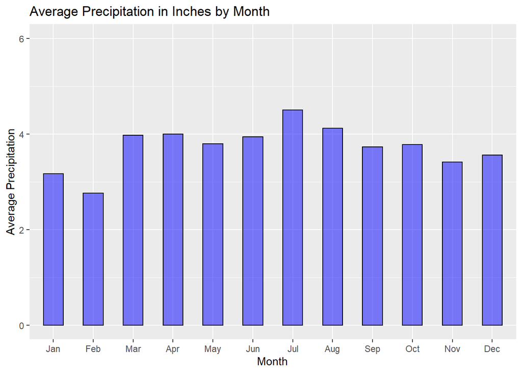

```r
ggplot(climateData, aes(x=Month, y=`Av Precip`)) +
  geom_bar(alpha = .5,
           stat = "identity",
           position = position_dodge(),
           fill="blue",
           width = 0.5,
           colour="black") +
  ylim(0, 6) +
  ggtitle("Average Precipitation in Inches by Month") +
  xlab("Month") +
  ylab("Average Precipitation")
```

### Snowfall

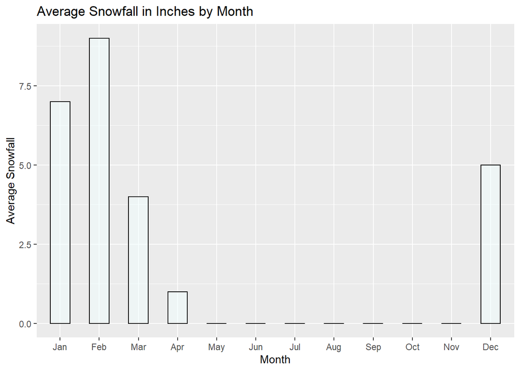

```r
ggplot(climateData, aes(x=Month, y=climateData$"Av Snowfall in inches")) +
  geom_bar(alpha = .5,
           stat = "identity",
           position = position_dodge(),
           fill="azure",
           width = 0.5,
           colour="black") +
  ggtitle("Average Snowfall in Inches by Month") +
  xlab("Month") +
  ylab("Average Snowfall")
```

### High and Low Temperature

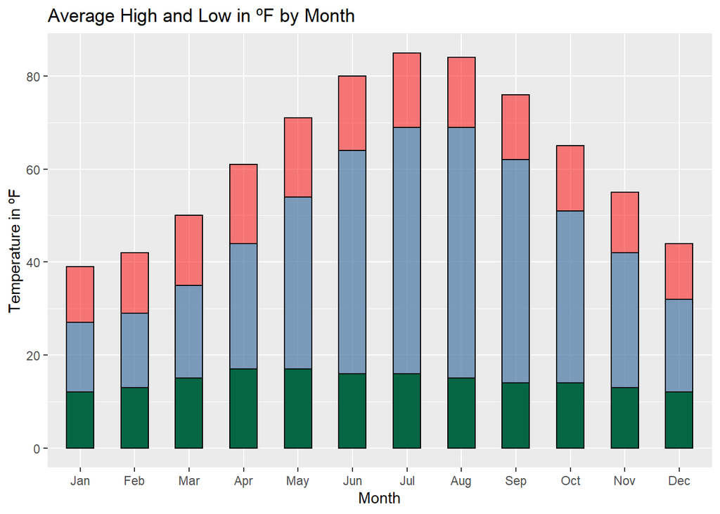

```r
ggplot(climateData, aes(x=Month)) +
  geom_bar(aes(y=climateData$"Av High in ºF"),
           alpha = .5,
           stat = "identity",
           position = position_dodge(),
           fill="red",
           width = 0.5,
           colour="black") +
  geom_bar(aes(y=climateData$"Av Low in ºF"),
           alpha = .5,
           stat = "identity",
           position = position_dodge(),
           fill="deepskyblue",
           width = 0.5,
           colour="black") +
  geom_bar(aes(y=climateData$"Av High in ºF" - climateData$"Av Low in ºF" ),
           stat = "identity",
           position = position_dodge(),
           fill="#056644",
           width = 0.5,
           colour="black") +
  ggtitle("Average High and Low in ºF by Month") +
  xlab("Month") +
  ylab("Temperature in ºF")
```

**Key**:  
High Temperature Low Temperature Difference between High and Low Temperature

# Corona Virus Data

The original corona virus data is from https://github.com/CryptoKass/ncov-data/blob/master/world.latest.bno.csv. I saved the csv to my GitHub account. Here is the [link.](https://raw.githubusercontent.com/logicalschema/DATA607/master/Project%202/corona.csv) The csv was straightforward except for the `notes` column which needs to be parsed with regular expressions.

## Importing

Let’s import the data from GitHub. A view of what is imported is below.

```r
coronaCSV <- read.csv("https://raw.githubusercontent.com/logicalschema/DATA607/master/Project%202/corona.csv")
coronaCSV
```

| X | country | cases | deaths | notes | links |
| --- | --- | --- | --- | --- | --- |
| 0 | China | 59804 | 1365 | 0 | https://bnonews.com/index.php/2020/02/the-latest-coronavirus-cases/ |
| 1 | Hong Kong | 50 | 1 | 4 critical, 2 serious, 1 recovered | https://edition.cnn.com/asia/live-news/coronavirus-outbreak-02-12-20-intl-hnk/h_b49323f6a8ba348a79c4cda5886339c7 |
| 2 | Taiwan | 18 | 0 | 1 recovered | https://www.cdc.gov.tw/Bulletin/Detail/iMZg3IYhKMeo-87fTw8hpQ?typeid=9 |
| 3 | Macau | 10 | 0 | 1 recovered | https://news.gov.mo/detail/zh-hant/N20BDPAzBd?3 |
| 4 | Japan | 247 | 0 | 4 serious, 4 recovered | https://www3.nhk.or.jp/nhkworld/en/news/20200213_29/ |
| 5 | Singapore | 50 | 0 | 8 critical, 15 recovered | https://www.moh.gov.sg/news-highlights/details/six-more-cases-discharged-three-new-cases-of-covid-19-infection-confirmed |
| 6 | Thailand | 33 | 0 | 1 serious, 10 recovered | https://pr.moph.go.th/?url=pr/detail/2/04/138459/ |
| 7 | South Korea | 28 | 0 | 7 recovered | https://en.yna.co.kr/view/AEN20200212007600320 |
| 8 | Malaysia | 18 | 0 | 3 recovered | https://www.channelnewsasia.com/news/asia/malaysia-recovered-wuhan-coronavirus-patients-china-embassy-12421116 |
| 9 | Australia | 15 | 0 | 8 recovered | https://www.smh.com.au/national/all-four-nsw-coronavirus-patients-free-from-disease-20200213-p540i9.html |

[output cut: 16 more lines]

```r
names(coronaCSV)
```

```
## [1] "X"       "country" "cases"   "deaths"  "notes"   "links"
```

A note about the csv, for `notes`, if the value is empty, there is a 0 otherwise there will be a comma-delimited list of fields for `critical`, `serious`, and `recovered`.

## Tidying

With the present state of the corona data, we will need to search through the `coronaCSV$notes` column and extrapolate new column values for `critical`, `serious`, and `recovered`. The initial column names are below.

```r
newColumns <- data.frame(matrix(ncol = 3, nrow = 0))
x <- c("critical", "serious", "recovered")
names(newColumns) <- x

#Declare variables for critical, serious, and recovered
c <- 0
s <- 0
r <- 0


colnames(coronaCSV)
```

```
## [1] "X"       "country" "cases"   "deaths"  "notes"   "links"
```

```r
items <- coronaCSV$notes

for (row in 1:length(items)){
  item <- items[row]

  #If the notes is "0", create an empty row element
  if (item == "0"){
    newColumns <- add_row(newColumns, "critical" = 0, "serious" = 0, "recovered" = 0)
  } else {
    note <- unlist(str_split(item, ","))

    #Obtain the critical value
    p <- grep("critical", note)
    if ( length(p) > 0){
      tempString <- note[p]
      tempString <- str_trim(str_replace(tempString, "critical", ""))
      c <- as.numeric(tempString)
    } else {
      c <- 0
    }

    #Obtain the serious value
    p <- grep("serious", note)
      if ( length(p) > 0){
      tempString <- note[p]
      tempString <- str_trim(str_replace(tempString, "serious", ""))
      s <- as.numeric(tempString)
    } else {
      s <- 0
    }

    #Obtain the serious value
    p <- grep("recovered", note)
      if ( length(p) > 0){
      tempString <- note[p]
      tempString <- str_trim(str_replace(tempString, "recovered", ""))
      r <- as.numeric(tempString)
    } else {
      r <- 0
    }

    newColumns <- add_row(newColumns, "critical" = c,"serious" = s,"recovered" = r)
  }
}

#Creating a new column to match newColumns with coronaCSV
id <- 0:25
newColumns["X"] <- id
coronaCSV <- merge(coronaCSV, newColumns)

names(coronaCSV)
```

```
## [1] "X"         "country"   "cases"     "deaths"    "notes"     "links"
## [7] "critical"  "serious"   "recovered"
```

```r
#Reordering the columns for coronaCSV
coronaCSV <- coronaCSV[c("X",
                         "country",
                         "cases",
                         "deaths",
                         "critical",
                         "serious",
                         "recovered",
                         "links",
                         "notes")]
```

After tidying the data, this is the new data.

```r
coronaCSV
```

| X | country | cases | deaths | critical | serious | recovered | links | notes |
| --- | --- | --- | --- | --- | --- | --- | --- | --- |
| 0 | China | 59804 | 1365 | 0 | 0 | 0 | https://bnonews.com/index.php/2020/02/the-latest-coronavirus-cases/ | 0 |
| 1 | Hong Kong | 50 | 1 | 4 | 2 | 1 | https://edition.cnn.com/asia/live-news/coronavirus-outbreak-02-12-20-intl-hnk/h_b49323f6a8ba348a79c4cda5886339c7 | 4 critical, 2 serious, 1 recovered |
| 2 | Taiwan | 18 | 0 | 0 | 0 | 1 | https://www.cdc.gov.tw/Bulletin/Detail/iMZg3IYhKMeo-87fTw8hpQ?typeid=9 | 1 recovered |
| 3 | Macau | 10 | 0 | 0 | 0 | 1 | https://news.gov.mo/detail/zh-hant/N20BDPAzBd?3 | 1 recovered |
| 4 | Japan | 247 | 0 | 0 | 4 | 4 | https://www3.nhk.or.jp/nhkworld/en/news/20200213_29/ | 4 serious, 4 recovered |
| 5 | Singapore | 50 | 0 | 8 | 0 | 15 | https://www.moh.gov.sg/news-highlights/details/six-more-cases-discharged-three-new-cases-of-covid-19-infection-confirmed | 8 critical, 15 recovered |
| 6 | Thailand | 33 | 0 | 0 | 1 | 10 | https://pr.moph.go.th/?url=pr/detail/2/04/138459/ | 1 serious, 10 recovered |
| 7 | South Korea | 28 | 0 | 0 | 0 | 7 | https://en.yna.co.kr/view/AEN20200212007600320 | 7 recovered |
| 8 | Malaysia | 18 | 0 | 0 | 0 | 3 | https://www.channelnewsasia.com/news/asia/malaysia-recovered-wuhan-coronavirus-patients-china-embassy-12421116 | 3 recovered |
| 9 | Australia | 15 | 0 | 0 | 0 | 8 | https://www.smh.com.au/national/all-four-nsw-coronavirus-patients-free-from-disease-20200213-p540i9.html | 8 recovered |

[output cut: 16 more lines]

## Analysis

We have finished tidying up the data. Now we can conduct a simple analysis of the data for `cases`, `deaths`, `critical`, `serious`, and `recovered`. The data is very skewed as China has reported the largest number of cases and there are no notes about the numbers of critical, serious, and recovered cases. The lack of media does shine a glaring spotlight on China.

```r
summary( coronaCSV %>%
           select(-links, -notes, -X)
)
```

```
##       country       cases             deaths           critical
##  Australia: 1   Min.   :    1.0   Min.   :   0.00   Min.   :0.0000
##  Cambodia : 1   1st Qu.:    3.0   1st Qu.:   0.00   1st Qu.:0.0000
##  Canada   : 1   Median :   10.5   Median :   0.00   Median :0.0000
##  China    : 1   Mean   : 2322.0   Mean   :  52.58   Mean   :0.4615
##  Finland  : 1   3rd Qu.:   18.0   3rd Qu.:   0.00   3rd Qu.:0.0000
##  France   : 1   Max.   :59804.0   Max.   :1365.00   Max.   :8.0000
##  (Other)  :20
##     serious         recovered
##  Min.   :0.0000   Min.   : 0.000
##  1st Qu.:0.0000   1st Qu.: 1.000
##  Median :0.0000   Median : 1.000
##  Mean   :0.4231   Mean   : 2.808
##  3rd Qu.:0.0000   3rd Qu.: 3.000
##  Max.   :4.0000   Max.   :15.000
##
```

Following are bar charts of the Corona data by variable broken down by country.

### Cases

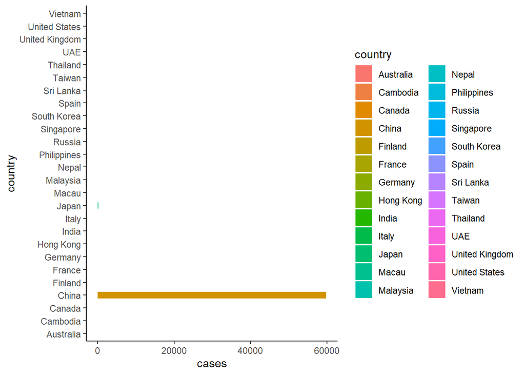

```r
ggplot(coronaCSV, aes(x = country, y = cases, fill = country)) +
    geom_bar(stat = "identity", width = 0.5) +
    coord_flip() +
    theme_classic()
```

### Deaths

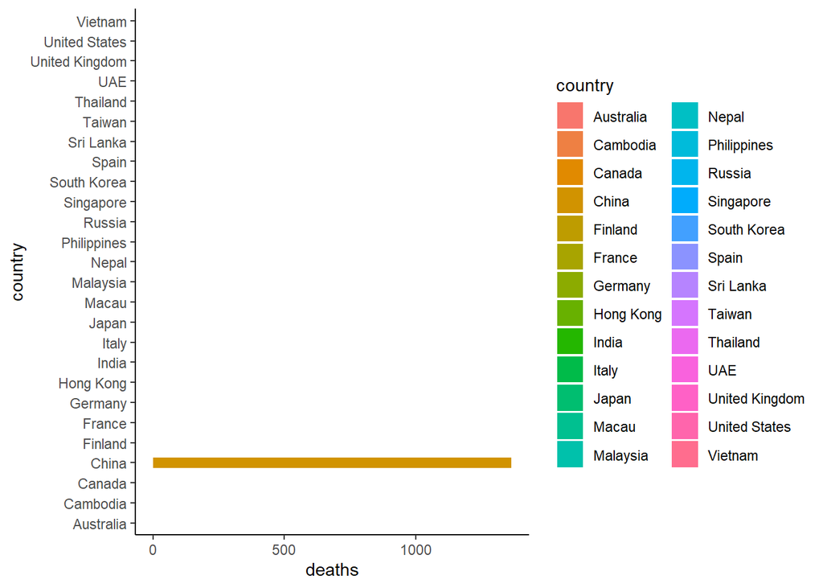

```r
ggplot(coronaCSV, aes(x = country, y = deaths, fill = country)) +
    geom_bar(stat = "identity", width = 0.5) +
    coord_flip() +
    theme_classic()
```

### Critical

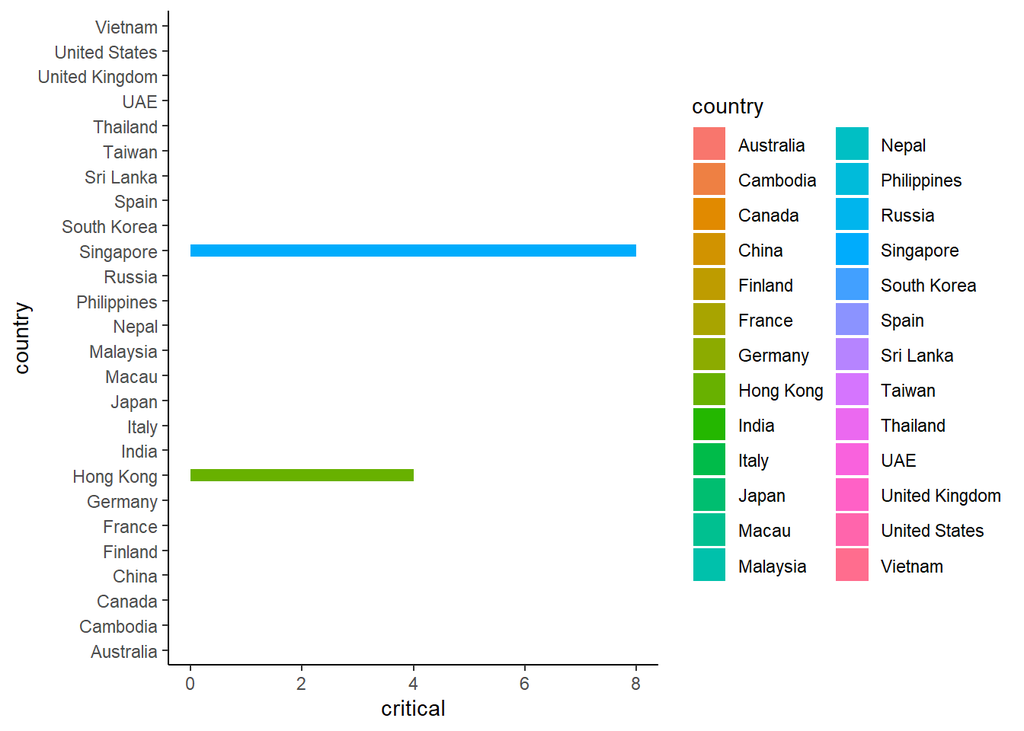

```r
ggplot(coronaCSV, aes(x = country, y = critical, fill = country)) +
    geom_bar(stat = "identity", width = 0.5) +
    coord_flip() +
    theme_classic()
```

### Serious

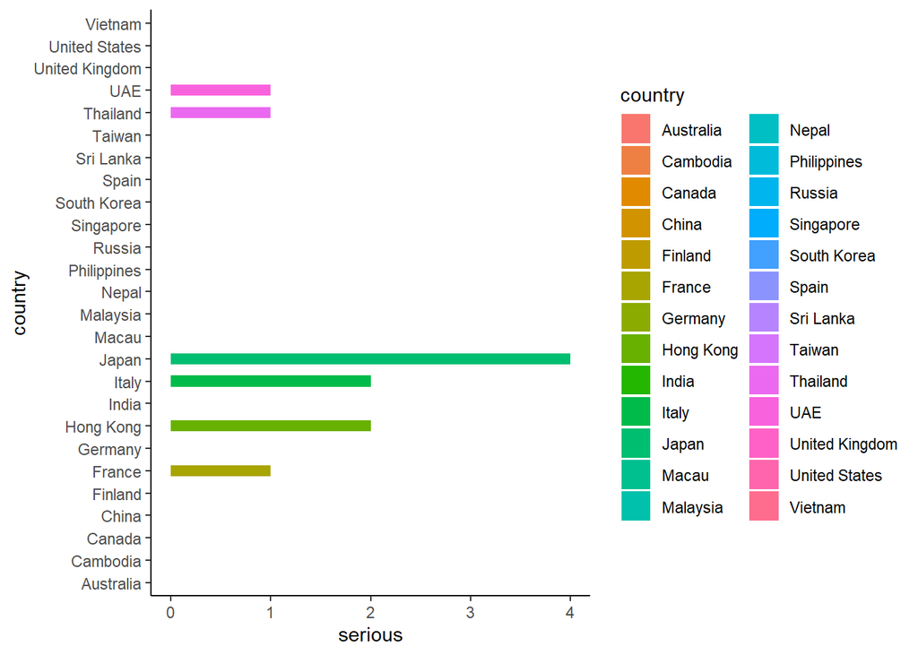

```r
ggplot(coronaCSV, aes(x = country, y = serious, fill = country)) +
    geom_bar(stat = "identity", width = 0.5) +
    coord_flip() +
    theme_classic()
```

### Recovered

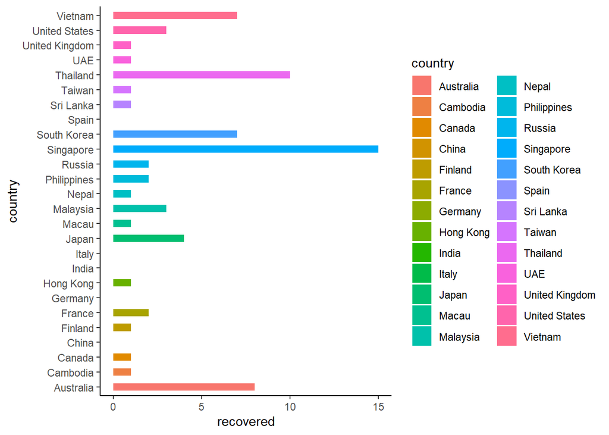

```r
ggplot(coronaCSV, aes(x = country, y = recovered, fill = country)) +
    geom_bar(stat = "identity", width = 0.5) +
    coord_flip() +
    theme_classic()
```

# Academic Advising Data

Gehad Gad provided a data set for tidying related to academic advising. Below is a screenshot of the data.

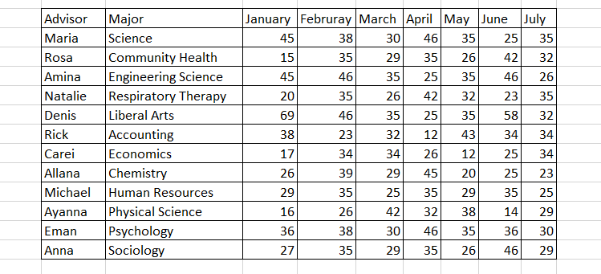

## Importing

To begin, let’s import the Academic Advising data using the GitHub file. Here is what the initial import looks like along with the column names.

```r
academicCSV <- read.csv("https://raw.githubusercontent.com/logicalschema/DATA607/master/Project%202/academicadvising.csv")
academicCSV
```

| ï..Advisor | Major | January | February | March | April | May | June | July |
| --- | --- | --- | --- | --- | --- | --- | --- | --- |
| Maria | Science | 45 | 38 | 30 | 46 | 35 | 25 | 35 |
| Rosa | Community Health | 15 | 35 | 29 | 35 | 26 | 42 | 32 |
| Amina | Engineering Science | 45 | 46 | 35 | 25 | 35 | 46 | 26 |
| Natalie | Respiratory Therapy | 20 | 35 | 26 | 42 | 32 | 23 | 35 |
| Denis | Liberal Arts | 69 | 46 | 35 | 25 | 35 | 58 | 32 |
| Rick | Accounting | 38 | 23 | 32 | 12 | 43 | 34 | 34 |
| Carei | Economics | 17 | 34 | 34 | 26 | 12 | 25 | 34 |
| Allana | Chemistry | 26 | 39 | 29 | 45 | 20 | 25 | 23 |
| Michael | Human Resources | 29 | 35 | 25 | 35 | 29 | 35 | 25 |
| Ayanna | Physical Science | 16 | 26 | 42 | 32 | 38 | 14 | 29 |

[output cut: 2 more lines]

```r
names(academicCSV)
```

```
## [1] "ï..Advisor" "Major"      "January"    "February"   "March"
## [6] "April"      "May"        "June"       "July"
```

## Tidying

The imported data needs some cleanup to be used for analysis. The `ï..Advisor` column name needs to be fixed and as proposed by Gehad, we can gather the month and rank data into two new column names.

Let’s rename the `ï..Advisor` column.

```r
academicCSV <- rename(academicCSV, "Advisor" = "ï..Advisor")
names(academicCSV)
```

```
## [1] "Advisor"  "Major"    "January"  "February" "March"    "April"    "May"
## [8] "June"     "July"
```

Next, let’s convert the month columns to rows with a new column named `Rank` for storing the values.

```r
academicCSV <- gather(academicCSV, key = "Month", value = "Rank", "January":"July")
```

Here is what the data looks like.

```r
academicCSV
```

| Advisor | Major | Month | Rank |
| --- | --- | --- | --- |
| Maria | Science | January | 45 |
| Rosa | Community Health | January | 15 |
| Amina | Engineering Science | January | 45 |
| Natalie | Respiratory Therapy | January | 20 |
| Denis | Liberal Arts | January | 69 |
| Rick | Accounting | January | 38 |
| Carei | Economics | January | 17 |
| Allana | Chemistry | January | 26 |
| Michael | Human Resources | January | 29 |
| Ayanna | Physical Science | January | 16 |

[output cut: 74 more lines]

```r
names(academicCSV)
```

```
## [1] "Advisor" "Major"   "Month"   "Rank"
```

## Analysis

After our data has been cleaned, we can begin analysis. Here is a general summary of the data.

```r
summary(academicCSV %>%
           select(-Advisor, -Month)
)
```

```
##                  Major         Rank
##  Accounting         : 7   Min.   :12.00
##  Chemistry          : 7   1st Qu.:26.00
##  Community Health   : 7   Median :34.00
##  Economics          : 7   Mean   :32.52
##  Engineering Science: 7   3rd Qu.:36.00
##  Human Resources    : 7   Max.   :69.00
##  (Other)            :42
```

```r
#Order the Months for plot
academicCSV$Month <- factor(academicCSV$Month, levels = month.name)
```

Here is a breakdown of the data.

### Advisor Rank

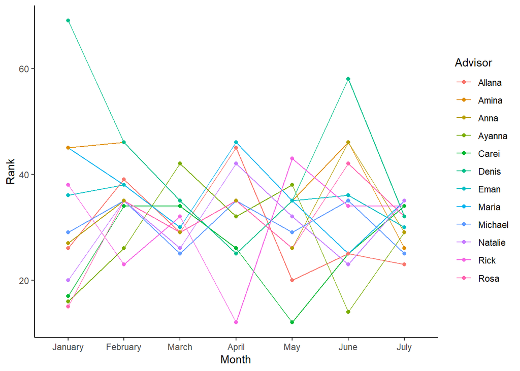

```r
ggplot(academicCSV, aes(x = Month, y = Rank, group = Advisor, color = Advisor)) +
  geom_line() +
  geom_point() +
  theme_classic()
```

### Major and Average Rank

Because each of the advisors is the unique advisor for the major, there is no noticeable difference from the plot for “Rank Over Time”

```r
meanMajor <- academicCSV %>%
                  group_by(Major, Month) %>%
                  summarise_at(vars(Rank),
                        list(Average = mean))
meanMajor
```

| Major | Month | Average |
| --- | --- | --- |
| Accounting | January | 38 |
| Accounting | February | 23 |
| Accounting | March | 32 |
| Accounting | April | 12 |
| Accounting | May | 43 |
| Accounting | June | 34 |
| Accounting | July | 34 |
| Chemistry | January | 26 |
| Chemistry | February | 39 |
| Chemistry | March | 29 |

[output cut: 74 more lines]

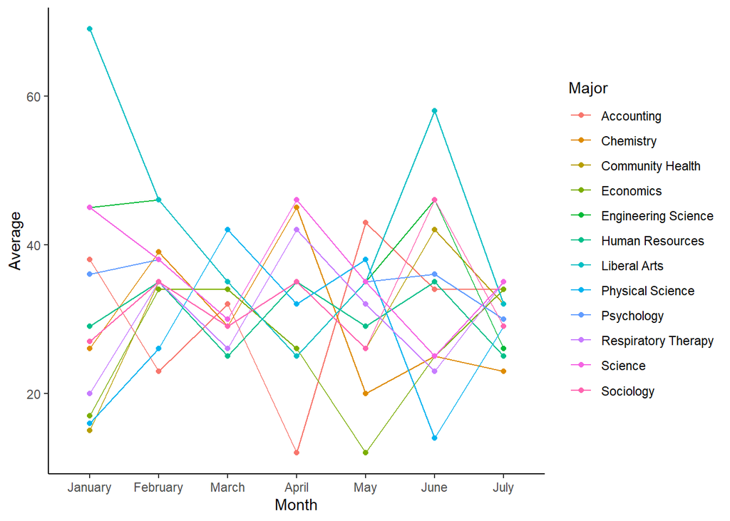

```r
ggplot(meanMajor, aes(x = Month, y = Average, group = Major, color = Major)) +
  geom_line() +
  geom_point() +
  theme_classic()
```

# Conclusion

R has many libraries that can help to wrangle, tidy, dice, and prepare data for analysis. Now, I have to endeavor in how to properly display the data analysis.